# Multinomial Naive Bayes

**Multinomial Naive Bayes:**

Multinomial Naive Bayes (MNB) is a supervised learning algorithm based on Bayes' Theorem with a strong (and "naive") assumption of feature independence. It can be thought of as a generalization of Benoulli Naive Bayes (with the likelihood of features being assumed to be a multinomial distribution instead of a bernoulli/binomial distribution, i.e. features assumed to exhibit discrete categories/values instead of binary 1s/0s). It's particularly well-suited for discrete features, especially in domains where the data is represented as counts or frequencies—such as text classification, document categorization, and spam detection.

**Theoretical Basis:**

1. **Bayes Theorem:**

A fundamental theorem in probability and statistics, which gives the relation between conditionals probabilities and probability distributions of random variables.

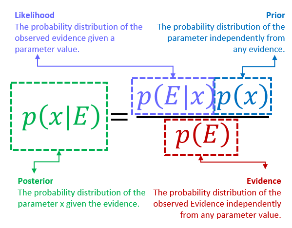

2. **The “Naive” Assumption:**

> The basis of all Naive Bayes models, the simplifying assumption that all features are conditionally independent of each other, i.e.

> $P(x1,\ x2,\ .\ .\ .\ ,\ xn\ |\ C)\ = \ P(x1\ |C)\ P(x2\ |\ C)\ .\ .\ .\ P(xn\ |\ C)\$

> Where xi = value of the i’th feature

> C = the class/label corresponding to the feature vector

> Note: $P(x,\ y)\ \equiv \ P(x \cap y)$
3. **The Multinomial Distribution:**

Where MNB differs from other NB models, is how it models the likelihood, i.e. $P(X|\ y)$.

MNB assumes the likelihood is a multinomial distribution, which means that each feature given y can have discrete values/labels associated with it and a fixed probability for each value/label.

For an example that will be followed for the rest of the article, an email-spam classifier, with the input feature-space corresponding with the count of each word appearing in an email.

p<sub>ki</sub> represents $P(i\ |\ C$<sub>k</sub>$)$, i.e. probability of i’th word occurring.]

**Estimation:**

To estimate the probability ($P(i\ |\ C$<sub>k</sub>$)$) of each word occurring in class C<sub>k</sub> (spam, not-spam), we use Maximum Likelihood Estimation (MLE).

We need: $P(y\ |\ X)$

$P(y\ |\ X)\ = \frac{P(X\ |\ y)\ P(y)}{P(X)}\$ *- from bayes’ theorem*

Since P(X) is a common factor in each case, independent of y, it can be ignored-

$P(y\ |\ X)\ \propto \ P(X\ |\ y)\ P(y)$

$P(X\ |y)\ = P(x1,\ x2,\ .\ .\ .\ ,\ xn\ |\ y)\ = \ P(x1\ |y)\ P(x2\ |\ y)\ .\ .\ .\ P(xn\ |\ y)\ \$*-from earlier assumption*

$P(y\ |\ X)\ \propto \ P(y)\ \prod_{i\ = \ 1}^{n}P(x$<sub>i</sub>$\ |\ y)$

Let:

$P(x$<sub>i</sub> $|\ y)\ =$ $\theta$$i\ |\ y$

$P(y\ = \ spam)\ = \ \phi$

To train the Multinomial Naive Bayes classifier, we estimate the parameters $\phi$ and $\theta$<sub>i</sub>$\ |\ y$ using Maximum Likelihood Estimation (MLE). That is, we choose the parameter values that maximize the likelihood of the training data.

The training set: {(X<sup>(i)</sup>, y<sup>(i)</sup>)}, for i = 1 to m;

Each X<sup>(i)</sup> = (x<sub>1</sub><sup>(i)</sup>, …., x<sub>n</sub><sup>(i)</sup>);

Likelihood of the whole dataset:

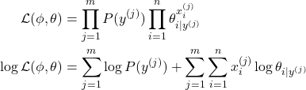

After solving for parameters: (Taking partial derivative and solving for 0)

Note: 1{...} is the indicator function,

$1\{ X\}\$ = ⎰ 1; X = True

⎱ 0; X = False

So basically: $\phi$<sub>y</sub> $= \ \frac{Number\ of\ spam\ documents}{Total\ number\ of\ documents}$

Similarly, for word likelihoods:

$\theta$$i\ |\ y$ $= \ \frac{1}{Ny}count(i,\ y)$

count(i, y) = Number of times the i’th word appears in documents of class y

**Smoothing:**

In practice, some words may not appear in the training data for every class, leading to zero probabilities. This is problematic because:

If any $\theta$$i|y$$\ = \ 0$ the whole product becomes 0, completely eliminating that class from consideration—even if it’s otherwise a good fit. To fix this, we use Laplace smoothing:

$\theta$<sub>i | y</sub> $= \ \frac{count(i,\ y)\ + \ \alpha}{Ny\ + \ \alpha n}$

count(i, y) = Number of times the i’th word appears in documents of class y

n = Vocabulary size

$\alpha\ = \$Smoothing constant, usually equal to 1

$\alpha\ = \ 1\$ adds one imaginary occurrence of every word in every class—making unseen words have small but nonzero probability.

**Testing / Inference Time:**

C<sub>k</sub> = k’th class

For our example case classes being spam and not-spam (1/0)

**Example:**

Let documents:

Suppose you’re building a spam filter. Your vocabulary consists of 5 words:

V = {free, win, money, click, hello}

| **Label** | **Message** |
| --- | --- |
| Spam | Free money click |
| Spam | Win money |
| Spam | Free free win |
| Not-spam | Hello hello click |
| Not-spam | Hello |
| Not-spam | Hello win |

1. **Computing Class Priors:**

> There are 3 spam and 3 not-spam messages:

> $P(spam)\ = \ \frac{3}{6}$ ; $P(not\ spam)\ = \ \frac{3}{6}$
2. **Counting word Frequencies:**

| **WORD** | **SPAM COUNT** | **NOT-SPAM COUNT** |
| --- | --- | --- |
| free | 3 | 0 |
| win | 2 | 1 |
| money | 2 | 0 |
| click | 1 | 1 |
| hello | 0 | 4 |
| **TOTAL** | 8 | 6 |

3. **Parameter-Calculations:**

> n = vocabulary size = 5

> $\alpha\ = \ 1$

> $\theta$$i\ |\ spam$ $= \frac{count(i,\ spam)\ + \ 1}{8\ + \ 5}\ = \frac{count\ + \ 1}{13}$

> $\theta$$i\ |\ not - spam$ $= \ \frac{count(i,\ not - spam)\ + \ 1}{6\ + \ 5}$ $= \ \frac{count\ + 1}{11}$

| **Word** | $\theta$$i\ \|\ spam$ |
| --- | --- |
| free | 4/13 |
| win | 3/13 |
| money | 3/13 |
| click | 2/13 |
| hello | 1/13 |

| **Word** | $\theta$$i\ \|\ not - spam$ |
| --- | --- |
| free | 1/11 |
| win | 2/11 |
| money | 1/11 |
| click | 2/11 |
| hello | 5/11 |

4. **Classifying new message:**

> New message : “Free money click”

> X =(free: 1, win: 0, money: 1, click: 1, hello: 0)

[figure not shown]

Links for more reading:

1. GeeksForGeeks article:

> https://www.geeksforgeeks.org/machine-learning/multinomial-naive-bayes/
2. Wikipedia MNB section:

> https://en.wikipedia.org/wiki/Naive_Bayes_classifier#:~:text=%5B12%5D-,Multinomial%20naive%20Bayes,-%5Bedit%5D
3. From sklearn documentation:

> https://scikit-learn.org/stable/modules/naive_bayes.html#:~:text=75%20points%20%3A%204-,1.9.2.%20Multinomial%20Naive%20Bayes,-%23
4. A kaggle Notebook with code example:

> https://www.kaggle.com/discussions/general/468420